# Análisis del desarrollo de la Cirrosis

Realizado por: Carolina Iglesias, Esther García, y Macarena Cuen

# 1. INTRODUCCIÓN

Colangitis biliar primaria, también llamada cirrosis, es una enfermedad crónica autoinmune en la cual los conductos biliares del hígado se destruyen progresivamente.

El bilis es un fluido, producido por el hígado, que contribuye en el proceso de la digestión, ocasiona la correcta absorción de vitaminas, e interviene en el desecho de colesterol, toxinas y glóbulos rojos desgastados. Una inflamación crónica en el hígado puede provocar daños en los conductos biliares, cicatrización irreversible en el tejido hepático (cirrosis) y finalmente, insuficiencia hepática.

Aunque esta condición afecta a ambos sexos, la cirrosis suele ser más común en mujeres. Los investigadores creen que una combinación de factores genéticos y ambientales generan la enfermedad. Esta condición suele desarrollarse lentamente y puede ser tratada para retrasar su avance, pero hasta el día de hoy, no existe una cura para dicha enfermedad. En este trabajo esperamos encontrar relación entre los diferentes marcadores que contribuyen al diagnóstico de la enfermedad.

[figure not shown]

# 2. SET DE DATOS

Para realizar un análisis sobre la enfermedad hemos utilizado un set de datos de la página web de hbiostat. La muestra está formada por 418 personas y se evalúan 19 variables. Estas variables son las siguientes:

| Variable | Descripción |
| --- | --- |
| bili | variable tipo double que indica el nivel de bilirrubina en la sangre medido en mg/dl |
| albumin | variable tipo double que indica el nivel de albumina en la sangre medido en gm/dl |
| stage | variable tipo double que indica el grado de la enfermedad según el criterio Ludwig: siendo 1 el grado donde solamente hay presencia de tejido anormal e inflamación y 4 el grado de mayor gravedad de la… |
| protime | variable tipo double que indica el tiempo de protrombina en segundos. (Tiempo que tarda la sangre en coagular) |
| sex | variable tipo interger que indica si es hombre o mujer |
| fu.days | variable tipo double que indica el tiempo de vida restante hasta la muerte o trasplante de hígado |
| age | variable tipo double que indica la edad del paciente en años |
| spiders | variable tipo interger que indica la existencia de angiomas aracniformes en la piel |
| hepatom | variable tipo interger que indica la presencia o ausencia de un tumor en el hígado |
| ascites | variable tipo interger que indica la presencia o ausencia de acumulación de líquido en el abdomen |
| alk.phos | variable tipo double que indica el nivel de fosfatasa alcalina en la sangre medido en U/litro |
| sgot | variable tipo double que indica el nivel de la proteína SGOT en la sangre medido en U/ml. Dicha proteína se filtra en la sangre cuando las células del hígado se dañan, por lo que las personas con cirr… |
| chol | variable tipo double que indica el nivel de colesterol en la sangre medido en mg/dl |
| trig | variable tipo double que indica el nivel de triglicéridos en la sangre medido en mg/dl |
| platelet | variable tipo double que indica el nivel de plaquetas por cm^3/1000 |
| drug | variable tipo interger que indica el tratamiento recibido: D-penicilina, placebo, no aleatoria |
| status | variable tipo double que indica el estado del paciente tras hacer un seguimiento |
| edema | variable tipo interger que indica la presencia de edema en el paciente: ausente o presente |
| copper | variable tipo double que indica el nivel de cobre en la orina medido en ug/día |

|  | bili | albumin | stage | protime | sex | fu.days | age | spiders | hepatom | ascites | alk.phos | sgot | chol | trig | platelet | drug | status | edema | copper |
| --- | --- | --- | --- | --- | --- | --- | --- | --- | --- | --- | --- | --- | --- | --- | --- | --- | --- | --- | --- |
| 1 | 14.5 | 2.60 | 4 | 12.2 | female | 400 | 58.76523 | present | present | present | 1718.0 | 137.95 | 261 | 172 | 190 | placebo | 1 | edema despite diuretic therapy | 156 |
| 2 | 1.1 | 4.14 | 3 | 10.6 | female | 4500 | 56.44627 | present | present | absent | 7394.8 | 113.52 | 302 | 88 | 221 | placebo | 0 | no edema | 54 |
| 3 | 1.4 | 3.48 | 4 | 12.0 | male | 1012 | 70.07255 | absent | absent | absent | 516.0 | 96.10 | 176 | 55 | 151 | placebo | 1 | edema, no diuretic therapy | 210 |
| 4 | 1.8 | 2.54 | 4 | 10.3 | female | 1925 | 54.74059 | present | present | absent | 6121.8 | 60.63 | 244 | 92 | 183 | placebo | 1 | edema, no diuretic therapy | 64 |
| 5 | 3.4 | 3.53 | 3 | 10.9 | female | 1504 | 38.10541 | present | present | absent | 671.0 | 113.15 | 279 | 72 | 136 | D-penicillamine | 0 | no edema | 143 |
| 6 | 0.8 | 3.98 | 3 | 11.0 | female | 2503 | 66.25873 | absent | present | absent | 944.0 | 93.00 | 248 | 63 | NA | D-penicillamine | 1 | no edema | 50 |
| 7 | 1.0 | 4.09 | 3 | 9.7 | female | 1832 | 55.53457 | absent | present | absent | 824.0 | 60.45 | 322 | 213 | 204 | D-penicillamine | 0 | no edema | 52 |
| 8 | 0.3 | 4.00 | 3 | 11.0 | female | 2466 | 53.05681 | absent | absent | absent | 4651.2 | 28.38 | 280 | 189 | 373 | D-penicillamine | 1 | no edema | 52 |
| 9 | 3.2 | 3.08 | 2 | 11.0 | female | 2400 | 42.50787 | present | absent | absent | 2276.0 | 144.15 | 562 | 88 | 251 | placebo | 1 | no edema | 79 |
| 10 | 12.6 | 2.74 | 4 | 11.5 | female | 51 | 70.55989 | present | absent | present | 918.0 | 147.25 | 200 | 143 | 302 | D-penicillamine | 1 | edema despite diuretic therapy | 140 |

# 3. PREGUNTAS

## 1. ¿Cómo varían las variables de nuestra data conforme avanza la enfermedad?

Para identificar la etapa de la enfermedad en la que está el paciente, ¿Qué valores de nuestra data set observamos que varían con el avance de la enfermedad?

### 1.1 Nivel de cobre en la orina

Para saber la relación del nivel de cobre con la cirrosis, planteamos:

> **H<sub>0</sub> (hipótesis nula)**: La media del nivel de cobre en la orina en todas las fases es igual.

> **H<sub>1</sub> (hipótesis alternativa)**: La media del nivel de cobre en la orina aumenta/disminuye conforme avanza la etapa de la enfermedad.

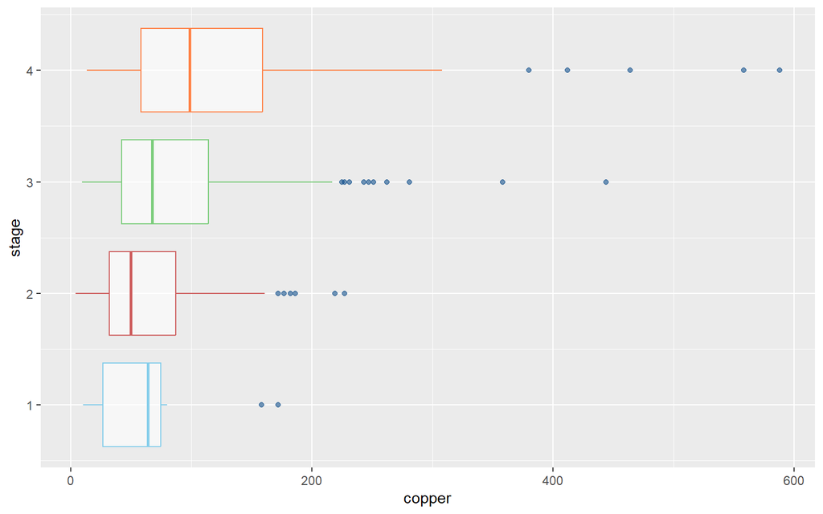

```r
stage1=subset(data, stage=='1',)
stage2=subset(data, stage=='2',)
stage3=subset(data, stage=='3',)
stage4=subset(data, stage=='4',)

ggplot()+
  geom_boxplot(stage1, mapping=aes(x=copper, y=stage), color="skyblue", alpha=0.6, outlier.color = "dodgerblue4")+
  geom_boxplot(stage2, mapping=aes(x=copper, y=stage), color="indianred", alpha=0.6, outlier.color = "dodgerblue4")+
  geom_boxplot(stage3, mapping=aes(x=copper, y=stage), color="palegreen3", alpha=0.6, outlier.color = "dodgerblue4")+
  geom_boxplot(stage4, mapping=aes(x=copper, y=stage), color="sienna1", alpha=0.6, outlier.color = "dodgerblue4")
```

Al ejecutar el código de los gráficos aparece una alerta que indica que se han excluido todas las filas en las cuales no había dato del paciente y en su lugar había “NA”.

Al graficar los datos se observa que estos muy probablemente no provienen de una distribución normal ya que contienen outliers. Por ello, hemos aplicado el Kruskal-Wallis test para identificar si existen diferencias significativas entre los niveles de cobre en la orina y la etapa de la enfermedad.

```r
kruskal.test(copper~stage, data)
```

```
##
##  Kruskal-Wallis rank sum test
##
## data:  copper by stage
## Kruskal-Wallis chi-squared = 27.549, df = 3, p-value = 4.517e-06
```

Observamos que el Kruskal test nos devuelve un p-value significativo por lo que aceptamos la hipótesis alternativa: conforme cambia la etapa de la enfermedad los niveles de cobre varían.

### 1.2 Ascitis

Realizamos un gráfico de barras para visulizar la presencia de ascitis en los pacientes, acumulación anormal de líquido en el abdomen.

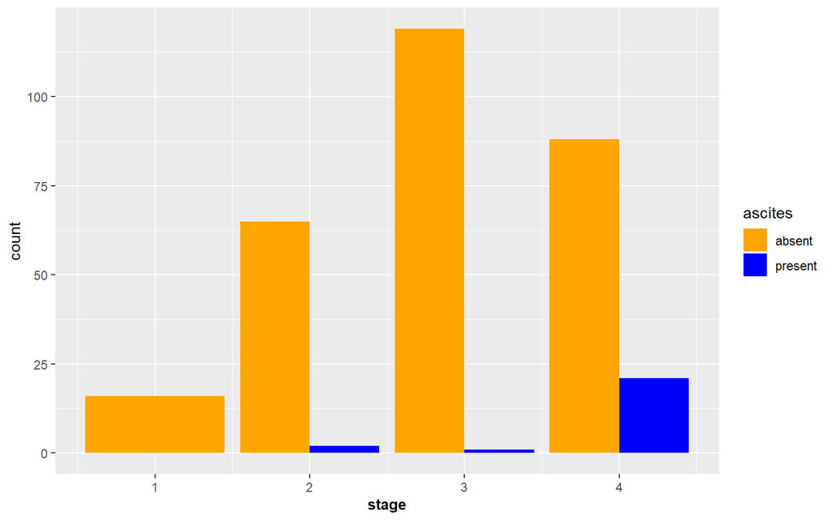

```r
data2<-subset(data, ascites!="NA")
g = ggplot(data2, aes(stage, fill=ascites))
g+geom_bar(position="dodge") + scale_fill_manual(values = alpha(c("orange", "blue"), 1)) +
  theme(axis.title.x = element_text(face="bold", size=10))
```

El gráfico de barras muestra que la presencia de ascitis se dispara para aquellos que están en la etapa de mayor gravedad.

Planteamos un T-test en el que:

> **H<sub>0</sub> (hipótesis nula)**: La media del número de etapa de la enfermedad es igual para pacientes con asicitis que sin ascitis.

> **H<sub>1</sub> (hipótesis alternativa)**: La media del número de etapa es mayor en aquellos pacientes con ascitis.

```r
ascites=subset(data, ascites=='present',)
no_ascites=subset(data, ascites=='absent',)
t.test(ascites$stage,no_ascites$stage, var.equal = TRUE, alternative = "greater")
```

```
##
##  Two Sample t-test
##
## data:  ascites$stage and no_ascites$stage
## t = 4.5497, df = 310, p-value = 3.86e-06
## alternative hypothesis: true difference in means is greater than 0
## 95 percent confidence interval:
##  0.5245152       Inf
## sample estimates:
## mean of x mean of y
##  3.791667  2.968750
```

Confirmamos nuestra hipótesis alternativa: los pacientes con ascitis se encuentran en etapas más avanzadas que los pacientes sin ascitis. Esta complicación suele ser muy frecuente cuando la enfermedad está avanzada e implica un empeoramiento drástico en el pronóstico del paciente. Tomando en cuenta que la causa más común de ascitis es la cirrosis, padecer ascitis, puede ser indicador de que el paciente se encuentra en la cuarta etapa, o cerca de llegar a ella.

La ascitis es causada por niveles bajos de albumina, por lo que la albumina también puede servirnos de indicador. Observamos el p-value del Wilcox test y el Boxplot para confirmar que, en efecto, en los pacientes con ascitis el nivel de albumina es menor.

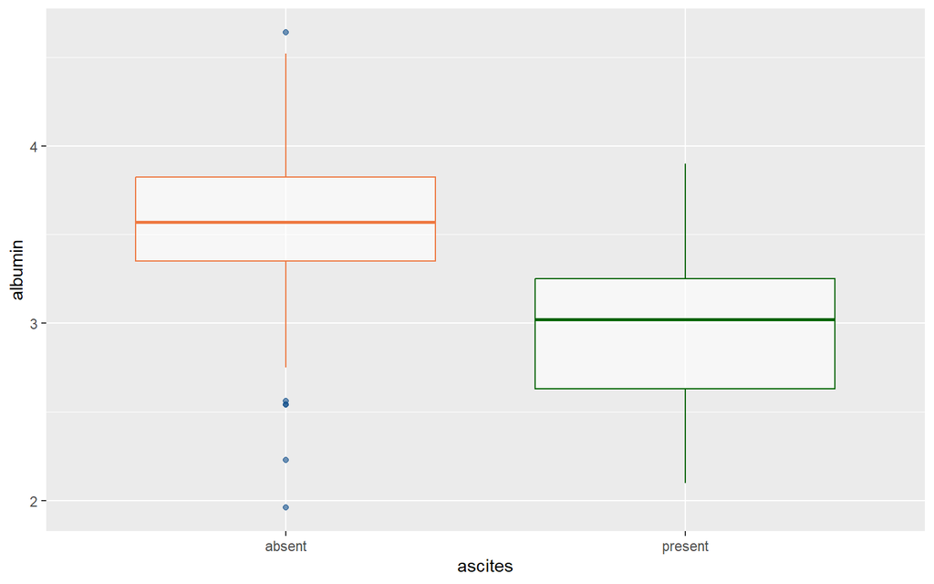

```r
ggplot()+
  geom_boxplot(ascites, mapping=aes(x=ascites, y=albumin), color="darkgreen", alpha=.6)+
  geom_boxplot(no_ascites, mapping=aes(x=ascites, y=albumin), color="sienna2", alpha=.6, outlier.color = "dodgerblue4")
```

```r
wilcox.test(ascites$albumin,no_ascites$albumin)
```

```
##
##  Wilcoxon rank sum test with continuity correction
##
## data:  ascites$albumin and no_ascites$albumin
## W = 1031, p-value = 1.127e-08
## alternative hypothesis: true location shift is not equal to 0
```

### 1.3 SGOT

Continuamos analizando la proteina sgot en la sangre, teniendo en cuenta que una concentración alta de esta enzima puede ser un signo de que el hígado está lesionado, irritado o ejerciendo un funcionamiento deficiente.

```r
data3=data
data3$stage=as.character(data3$stage)
stage1=subset(data3, stage=='1',)
stage4=subset(data3, stage=='4',)

t.test(stage1$sgot,stage4$sgot)
```

```
##
##  Welch Two Sample t-test
##
## data:  stage1$sgot and stage4$sgot
## t = -3.8575, df = 22.704, p-value = 0.0008158
## alternative hypothesis: true difference in means is not equal to 0
## 95 percent confidence interval:
##  -70.74555 -21.33133
## sample estimates:
## mean of x mean of y
##   84.4600  130.4984
```

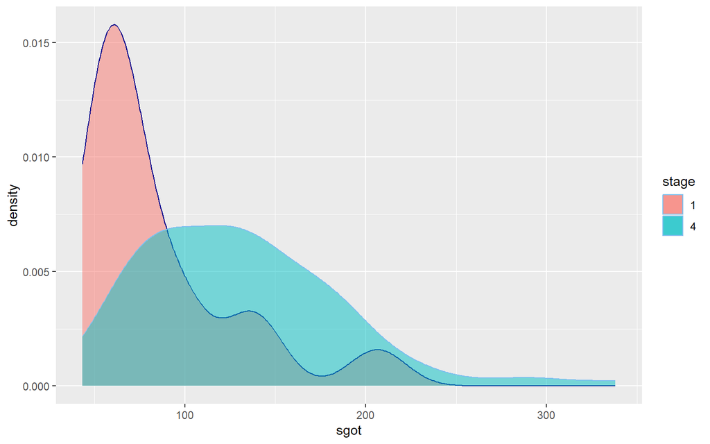

```r
ggplot()+
  geom_density(stage1, mapping=aes(x=sgot, group=stage, fill=stage), color="darkblue", alpha=0.5)+
  geom_density(stage4, mapping=aes(x=sgot, group=stage, fill=stage), color="skyblue2", alpha=0.5)
```

Vemos que los pacientes en una etapa más temprana de la enfermedad presentan niveles más bajos de SGOT (etapa 1), y analizando la etapa final (etapa 4), muchos pacientes presentan un aumento en la concentración de la enzima.

Viendo los resultados del T-test también confirmamos que, en efecto, hay una diferencia significativa en las medias del sgot en sangre entre pacientes de la etapa 1 y la etapa 4, siendo la media mayor para pacientes en la etapa 4.

Por lo que otro indicador de que la cirrosis está avanzando es el aumento en el nivel de SGOT en la sangre.

### 1.4 Tiempo de protrombina

El tiempo de protrombina es el tiempo que tarda la sangre en coagular (medida en segundos). Cuando el tiempo de protrombina es alto, la sangre tarda más tiempo en coagular. Esto usualmente sucede porque el hígado no está produciendo la cantidad adecuada de proteínas coagulantes, por lo que el proceso de coagulación tarda más tiempo. Por ello, nos planteamos que el aumento en el tiempo de protombina sea indicador de que el paciente está empeorando.

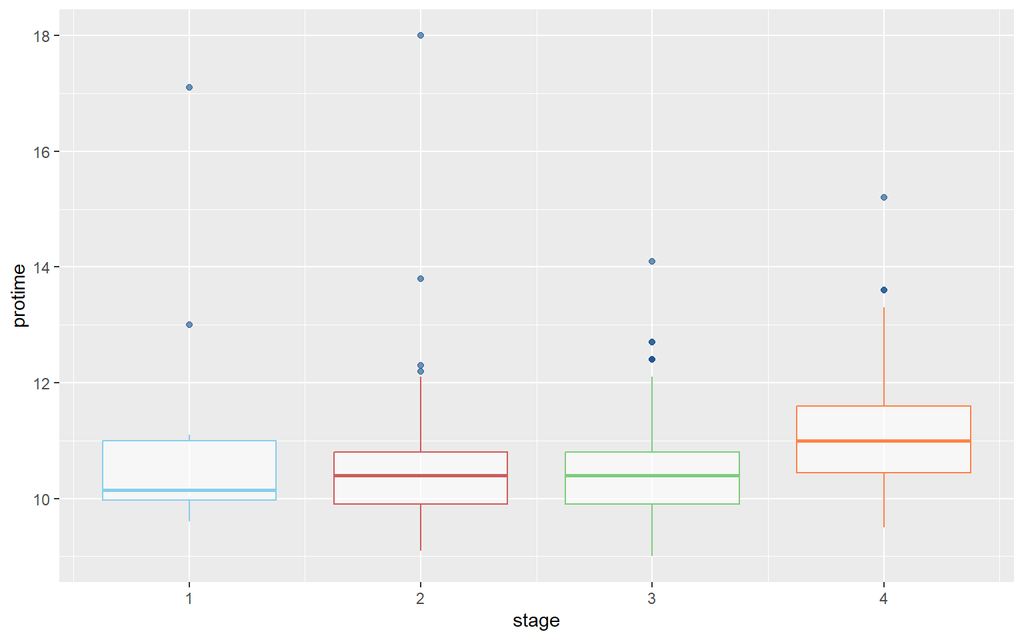

```r
stage1=subset(data, stage=='1',)
stage2=subset(data, stage=='2',)
stage3=subset(data, stage=='3',)
stage4=subset(data, stage=='4',)


ggplot()+
  geom_boxplot(stage1, mapping=aes(x=stage, y=protime), color="skyblue", alpha=0.6, outlier.color = "dodgerblue4")+
  geom_boxplot(stage2, mapping=aes(x=stage, y=protime), color="indianred", alpha=0.6, outlier.color = "dodgerblue4")+
  geom_boxplot(stage3, mapping=aes(x=stage, y=protime), color="palegreen3", alpha=0.6, outlier.color = "dodgerblue4")+
  geom_boxplot(stage4, mapping=aes(x=stage, y=protime), color="sienna1", alpha=0.6, outlier.color = "dodgerblue4")
```

```r
kruskal.test(protime~stage, data)
```

```
##
##  Kruskal-Wallis rank sum test
##
## data:  protime by stage
## Kruskal-Wallis chi-squared = 52.474, df = 3, p-value = 2.373e-11
```

Como podemos comprobar con el Kruskal-Wallis test, hay una significancia en la diferencia de medias de los tiempos de protrombina de cada fase. Un tiempo de protrombina alto usualmente es signo de grave daño en el hígado o cirrosis, lo confirmamos de igual manera observando el boxplot, y viendo como a medida que avanza la etapa de la enfermedad, hay más pacientes con tiempos de protrombina superiores a los de las etapas anteriores.

## 2. ¿Existe alguna diferencia en la manifestación de la enfermedad entre hombres y mujeres?

Según investigaciones, las mujeres son más propensas a desarrollar una cirrosis. Estadísticamente se ha podido comprobar que esta enfermedad es más común entre las mujeres. Por ello, en nuestra muestra, la mayoría de los pacientes son mujeres.

Independientemente de esto, ¿en qué valores de nuestro dataset se puede identificar alguna relación o diferencia entre los dos sexos?

### 2.1 Introduciendo el problema

Primero separamos el dataset según género para poder analizar mejor los resultados, entre hombres y mujeres.

```r
female=subset(data, sex=='female',)
male=subset(data, sex=='male',)
```

Para poder crear y utilizar las siguientes gráficas, hemos tenido que descargar el paquete ‘ggridges’.

```r
library(ggridges)
```

Para empezar vamos a coger los datos de los niveles de cobre, colesterol, trigliceridos, bilirubina, aspartato aminotransferasa(SGOT), y plaquetas. Creando unas gráficas separadas por género, y asi analizamos, a primera vista, las posibles diferencias con cada una de estas variables.

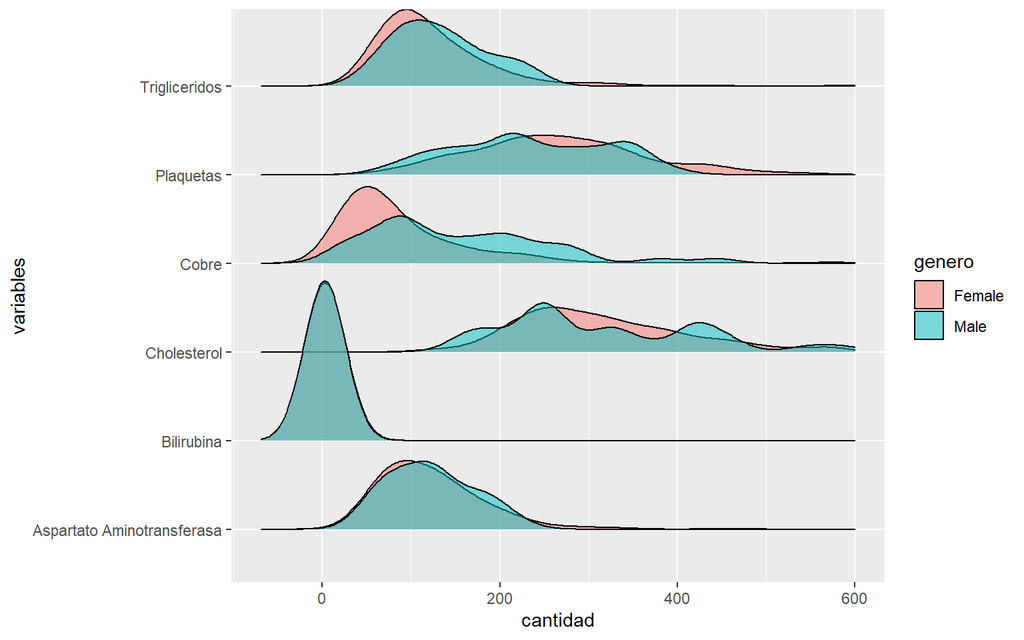

```r
cantidad=c(male$copper, male$chol, male$trig, male$bili, male$sgot, male$platelet)
variables=c(rep('Cobre', length(male$copper)), rep('Cholesterol', length(male$chol)),
          rep('Trigliceridos', length(male$trig)), rep('Bilirubina', length(male$bili)),
          rep('Aspartato Aminotransferasa', length(male$sgot)),
          rep('Plaquetas', length(male$platelet)))
genero=c(rep('Male', length(male$sex)))
dfhombre=data.frame(cantidad, variables, genero)

cantidad=c(female$copper, female$chol, female$trig, female$bili, female$sgot, female$platelet)
variables=c(rep('Cobre', length(female$copper)), rep('Cholesterol', length(female$chol)),
          rep('Trigliceridos', length(female$trig)), rep('Bilirubina', length(female$bili)),
          rep('Aspartato Aminotransferasa', length(female$sgot)),
          rep('Plaquetas', length(female$platelet)))
genero=c(rep('Female', length(female$sex)))
dfmujer=data.frame(cantidad, variables, genero)

dftodos=rbind(dfmujer, dfhombre)

ggplot(dftodos, aes(x=cantidad, y=variables, fill=genero))+
  geom_density_ridges(alpha=0.5)+
  xlim(NA, 600)
```

Este gráfico no se ve influido por el desequilibrio de mujeres y hombres en la muestra, ya que al ser funciones de densidad, indican la distribución de los datos de los hombres y mujeres en separado sin importar que hay más datos en un grupo que en el otro. Es probable que la información de los hombres no sea representativa por el tamaño tan pequeño del grupo masculino, pero por ello estamos corroborando todas las conclusiones de nuestra investigación con otras investigaciones e información de la comunidad científica.

Como podemos observar en estos graficos, los hombres suelen tener mayores niveles de triglicéridos y cobre que las mujeres. Podemos decir, que se puede ver en el gráfico que los niveles de los hombres para cada elemento suelen estar mas distrubuidos. Sin embargo, según el gráfico, están mas concentrados en una area. En cambio, según la gráfica, parece que el nivel de bilirrubina se distribuye exactamente igual en los hombres y en las mujeres.

Ahora vamos a analizar en casos más concretos donde no es tan fácil visualizar una  
diferencia considerable con una densidad general de todos los datos.

### 2.2 Nivel de plaquetas segun género y tratamiento

Aunque no se vea tan claro con el gráfico de densidad sabemos, despues de investigar, que en hombres los niveles de plaquetas suelen ser menores que en mujeres. En nuestro caso, más concretamente, esto se cumple dentro de los pacientes que estan recibiendo el tratamiento de D-penicillamine.

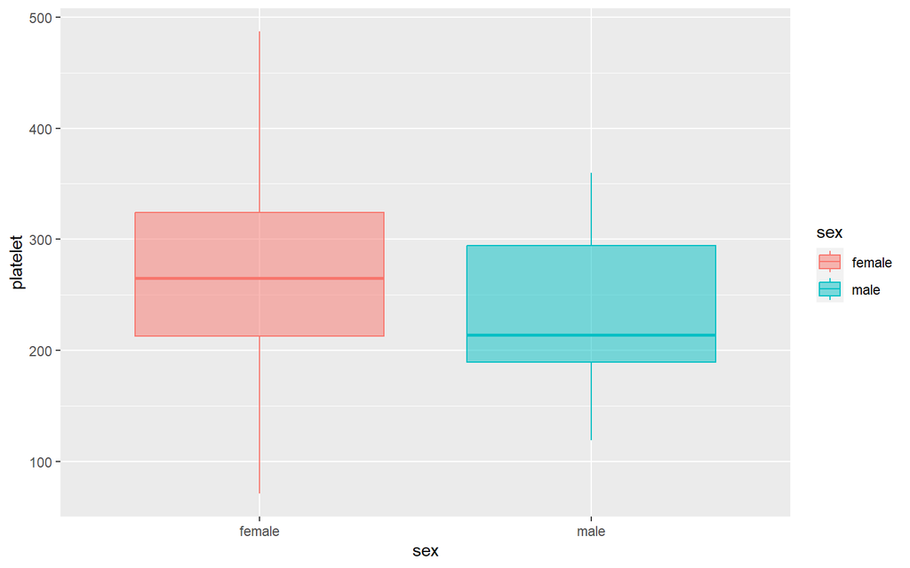

```r
penicilina=data[data$drug=="D-penicillamine",]
ggplot(penicilina, mapping=aes(x=sex, y=platelet, fill=sex, color=sex))+
  geom_boxplot(alpha=0.5)
```

Pero se cumple también con toda la muestra en general, independientemente del tratamiento que están recibiendo.

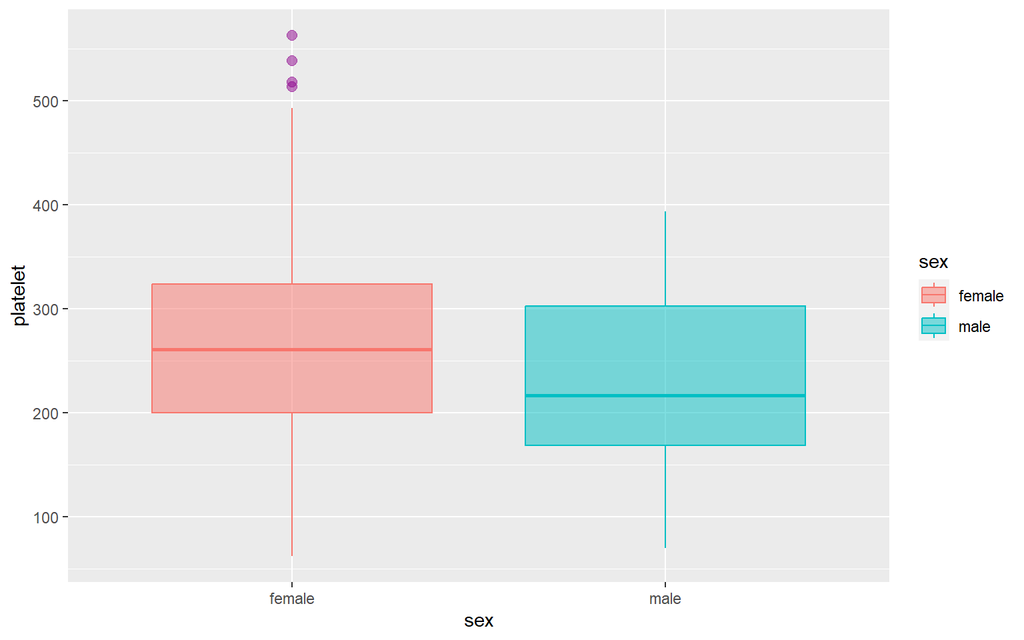

```r
ggplot(data, mapping=aes(x=sex, y=platelet, fill=sex, color=sex))+
  geom_boxplot(alpha=0.5, outlier.color="darkmagenta", outlier.size = 2.5)
```

En este boxplot se puede ver, que al tener en cuenta todos los datos de la muestra hay algunos outliers, como es de esperar al estar analizando tantos datos. En los dos boxplots se ve claramente que las mujeres tienen niveles mayores de plaquetas.

### 2.3 Edema y Bilirubina

En el gráfico de densidad identificamos que la bilirrubina se distribuye de igual manera en los hombres que en las mujeres. Siendo una variable en la que nos podemos enfocar para comparar los datos mejor, utilizaremos la variable edema para encontrar esta diferencia.

La variable “edema” se refiere a los pacientes que tienen las piernas hinchadas a causa de la enfermedad, esto suele darse mayoritariamente en los pacientes con la enfermedad bastante avanzada. Al tomar los pacientes con edema de nuestra muestra, las mujeres tienen niveles de bilirrubina más altos que los hombres. Este suceso es contrario a lo que suele suceder en personas sanas, ya que los hombres suelen tener niveles de bilirrubina más altos que las mujeres.

Primero nos descargamos el paquete ‘data.table’, para poder escoger correctamente los distintos datos que tiene la variable edema y clasificar por categorías.

```r
library(data.table)
```

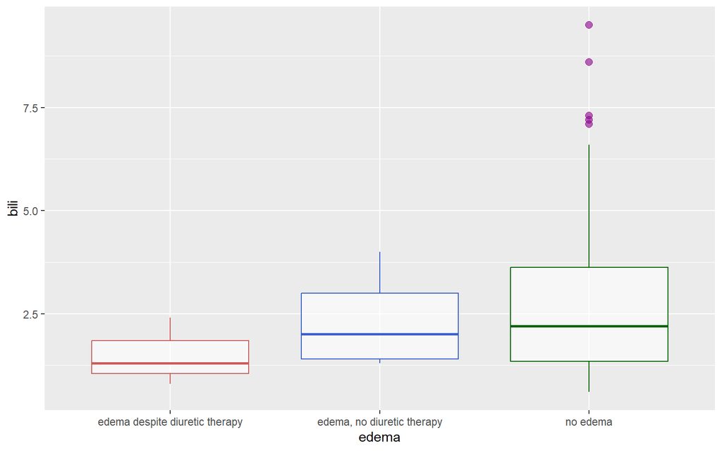

```r
noedema=male[male$edema %like% "no edema", ]
edemath=male[male$edema %like% "despite diuretic", ]
edemanth=male[male$edema %like% "no diuretic", ]


ggplot()+
  geom_boxplot(noedema, mapping=aes(x=edema, y=bili), color="darkgreen", alpha=0.6,
               outlier.color="darkmagenta", outlier.size = 2.5)+
  geom_boxplot(edemath, mapping=aes(x=edema, y=bili), color="indianred", alpha=0.6,
               outlier.color="darkmagenta", outlier.size = 2.5)+
  geom_boxplot(edemanth, mapping=aes(x=edema, y=bili), color="royalblue3", alpha=0.6,
               outlier.color="darkmagenta", outlier.size = 2.5)
```

Para analizar la gráfica hay que tener en cuenta que la mayoría de los pacientes hombres no tienen edema. Primero, con estos boxplots confirmamos que los hombres que no tienen edema tienen niveles de bilirubina más altos que los hombres que tienen edema, sin o con terapía diurética.

Ahora creamos el boxplot para la mujeres para ver como se distribuyen según el edema y la bilirubina.

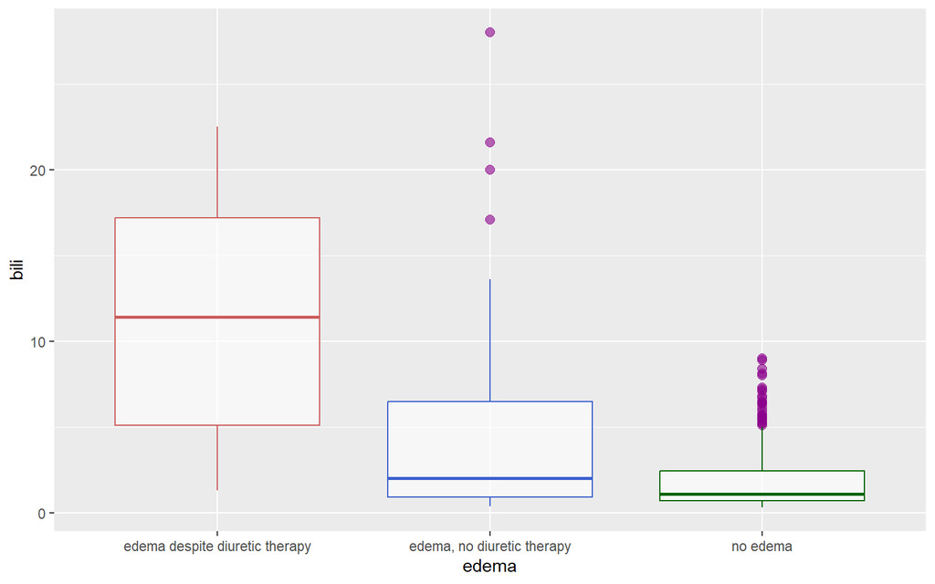

```r
noedemaf=female[female$edema %like% "no edema", ]
outlier=which(noedemaf$bili>10)
noedemaf=noedemaf[-outlier,]
edemathf=female[female$edema %like% "despite diuretic", ]
edemanthf=female[female$edema %like% "no diuretic", ]

ggplot()+
  geom_boxplot(noedemaf, mapping=aes(x=edema, y=bili), color="darkgreen", alpha=0.6,
               outlier.color="darkmagenta", outlier.size = 2.5)+
  geom_boxplot(edemathf, mapping=aes(x=edema, y=bili), color="indianred", alpha=0.6,
               outlier.color="darkmagenta", outlier.size = 2.5)+
  geom_boxplot(edemanthf, mapping=aes(x=edema, y=bili), color="royalblue3", alpha=0.6,
               outlier.color="darkmagenta", outlier.size = 2.5)
```

En estos boxplots de las mujeres, hemos tenido que quitar algunos outliers de la categoría de no edema, ya que al final no aportan al resultado. Sabemos que al haber más pacientes sin edema habría más outliers.

Aquí, al contrario que los hombres, se puede ver claramente que las mujeres tienen, con gran diferencia, niveles de bilirubina altos cuando tienen edema, especialmente con terapía diurética. Las gráficas de de las mujeres muestran resultados contrarios a los que se reflejan en las gráficas de los hombres.

## 3. ¿Podríamos predecir el tiempo de vida restante del paciente con las variables proporcionadas en el data set?

```r
library(MASS)
misubset <- data
to_remove <- which(is.na(misubset),arr.ind = TRUE)
files_a_eleminiar <- unique(to_remove)
data3 <- misubset[-files_a_eleminiar,]
model=lm(fu.days~., data=data3)
summary(model)
modelAIC=stepAIC(model, direction="backward")
```

[output not shown]

```r
model2=lm(fu.days~bili+albumin+protime+stage+alk.phos+status+copper, data=data)
summary(model2)
```

```
##
## Call:
## lm(formula = fu.days ~ bili + albumin + protime + stage + alk.phos +
##     status + copper, data = data)
##
## Residuals:
##      Min       1Q   Median       3Q      Max
## -2258.53  -532.88   -51.12   493.69  2279.52
##
## Coefficients:
##               Estimate Std. Error t value Pr(>|t|)
## (Intercept) -799.37862  795.79727  -1.005 0.315942
## bili         -58.14074   13.24954  -4.388 1.58e-05 ***
## albumin      668.37489  130.10968   5.137 5.02e-07 ***
## protime      128.45894   55.24817   2.325 0.020728 *
## stage       -209.01000   61.92000  -3.375 0.000833 ***
## alk.phos       0.14463    0.02361   6.127 2.80e-09 ***
## status      -492.88140  122.63030  -4.019 7.38e-05 ***
## copper        -1.92783    0.66772  -2.887 0.004168 **
## ---
## Signif. codes:  0 '***' 0.001 '**' 0.01 '*' 0.05 '.' 0.1 ' ' 1
##
## Residual standard error: 858.1 on 302 degrees of freedom
##   (108 observations deleted due to missingness)
## Multiple R-squared:  0.4313, Adjusted R-squared:  0.4181
## F-statistic: 32.71 on 7 and 302 DF,  p-value: < 2.2e-16
```

Con este modelo intentamos predecir el tiempo de vida restante en días de un paciente. Hemos tomado los datos de un paciente de nuestro data set que tenía 400 días de vida restantes en fu.days.

```r
paciente1<-matrix(c(14.3, 2.6, 12.2, 4, 1718, 1, 156),nrow=1,byrow=F)
colnames(paciente1)<-c("bili","albumin","protime","stage","alk.phos","status","copper")
paciente1=as.data.frame(paciente1)
predict(model2, paciente1, interval="confidence", level = 0.95) #mean
```

```
##       fit      lwr      upr
## 1 292.986 -9.63515 595.6071
```

```r
predict(model2, paciente1, interval="prediction", level = 0.95) #estimation
```

```
##       fit       lwr      upr
## 1 292.986 -1422.526 2008.498
```

Observamos que los 400 días de vida restante del paciente se encuentran dentro del intervalo de confianza de la media y de la estimación. Aún así consideramos la posibilidad de mejorar el modelo para poder predecir mejor, y por ello desarrollamos otro modelo lineal con el objetivo de maximizar el R cuadrado.

```r
model3=lm(fu.days~.*.,data=data)
a=summary(model3)
a$r.squared
```

```
## [1] 0.8064605
```

Es evidente que este modelo tiene un mayor R cuadrado, por lo que sería más acertado al predecir.

A pesar de ser un modelo más acertado, es verdad que hay que proporcionarle una mayor cantidad de datos, ya que toma como variables la multiplicación entre los diferentes valores. Por ello, no hemos podido hacer predicciones con este nuevo modelo.

# 4. CONCLUSIONES

Por medio de este trabajo hemos podido explorar múltiples correlaciones entre las diferentes variables del dataset. Hemos podido ver como algunas de las variables seguían un determinado comportamiento conforme variaba la etapa de la enfermedad y podían funcionar como indicadores del desarrollo o avance de la enfermedad.

Por un lado, el nivel de cobre en la orina, nivel de proteína SGOT en la sangre y el tiempo de protrombina son variables que suelen aumentar con el progreso de la enfermedad. Así también, la presencia de ascitis y un nivel bajo de albumina son más comunes en pacientes en etapas más avanzadas.

Por otro lado, en lo referente a las variables que se comportan de manera diferente en hombres y en mujeres sobresalen los triglicéridos y cobre, ya que los hombres suelen tener mayores niveles de triglicéridos y cobre que las mujeres. Luego hemos concluido que se cumple que las mujeres tienen niveles de plaquetas más altos que los hombres. Al tomar en cuenta la variable edema vemos que su presencia afecta los niveles de bilirubina en los pacientes: en las mujeres hace que aumente, y en los hombres disminuye.

Por ultimo, hemos creado un modelo lineal que predice el tiempo de vida restante del paciente con variables de nuestro data set.